# PA1 OJ: Minute Maid vs Citrus Hill Purchases

1/9/20

Repo: https://github.com/ehestekin/MSBA_5210_DataVis

```r
# Load Data
oj_data <- read.csv("OJ_Data.csv")

# View first few rows of data
head(oj_data, 3)
```

```
##   Id Purchase PriceCH PriceMM DiscCH DiscMM SpecialCH SpecialMM STORE
## 1  1       CH    1.75    1.99   0.00    0.0         0         0     1
## 2  2       CH    1.75    1.99   0.00    0.3         0         1     1
## 3  3       CH    1.86    2.09   0.17    0.0         0         0     1
```

# 1 Are the distributions symmetric or skewed?

```r
summary(oj_data)
```

```
##        Id         Purchase    PriceCH         PriceMM
##  Min.   :   1.0   CH:653   Min.   :1.690   Min.   :1.690
##  1st Qu.: 268.2   MM:417   1st Qu.:1.790   1st Qu.:1.990
##  Median : 535.5            Median :1.860   Median :2.090
##  Mean   : 535.5            Mean   :1.867   Mean   :2.085
##  3rd Qu.: 802.8            3rd Qu.:1.990   3rd Qu.:2.180
##  Max.   :1070.0            Max.   :2.090   Max.   :2.290
##      DiscCH            DiscMM         SpecialCH        SpecialMM
##  Min.   :0.00000   Min.   :0.0000   Min.   :0.0000   Min.   :0.0000
##  1st Qu.:0.00000   1st Qu.:0.0000   1st Qu.:0.0000   1st Qu.:0.0000
##  Median :0.00000   Median :0.0000   Median :0.0000   Median :0.0000
##  Mean   :0.05186   Mean   :0.1234   Mean   :0.1477   Mean   :0.1617
##  3rd Qu.:0.00000   3rd Qu.:0.2300   3rd Qu.:0.0000   3rd Qu.:0.0000
##  Max.   :0.50000   Max.   :0.8000   Max.   :1.0000   Max.   :1.0000
##      STORE
##  Min.   :0.000
##  1st Qu.:0.000
##  Median :2.000
##  Mean   :1.631
##  3rd Qu.:3.000
##  Max.   :4.000
```

- The distributions of price are very symmetric.
- The distributions of discounts are not symmetric.
  - This is likely explained by how infrequently discounts are offered.
- Citrus Hill accounted for 61.03 % of sales
- Skewness affects whether we can use a normal regression (need normal dist) or not (when it is skewed)

# 2 Which brand sells the most?

- Citrus Hill sells more (61% of sales)
- This may be due to price or ammount of discounts

```r
# add column for which price is lower (must account for discount)
oj_data <- mutate(oj_data, ch_lower_price = (PriceCH - DiscCH) < (PriceMM - DiscMM))

#test affect of lower price on purchase TODO
```

# 3 Which store sells the most OJ?

```r
#count occurences of each store
per_store_sales <- count(oj_data, STORE)
```

- Store 0 sold the most OJ with 356 sales

# 4 More variables to add?

- Above in the ‘Which brand sells the most’ section, I added a column for which brand had a lower price for a given sale datapoint.
- It would also be good to filter down discounts to only where discounts applied to get a better idea of the effect they have

# 5 Other comments/questions from EDA of data?

- It would be interesting to know the percent of sales of each brand at each store.
- It would also be interesting to see if the price/discounts has a different effect at different stores. Maybe some stores have less price-sensative shoppers.

# 6 Graphical Analysis

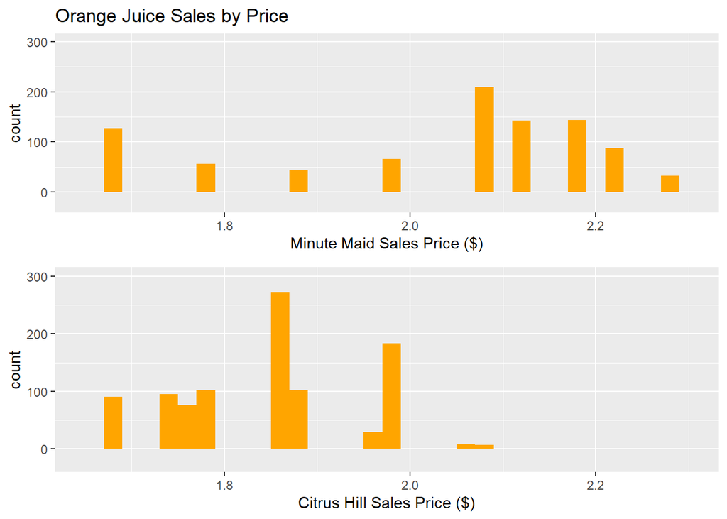

```r
grid.arrange(
ggplot(data = oj_data, mapping = aes(x = PriceMM - DiscMM)) +
  geom_histogram(binwidth = 0.02, fill = 'orange') +
  xlim(1.65,2.3) +
  ylim(-25, 300) +
  xlab('Minute Maid Sales Price ($)') +
  ggtitle('Orange Juice Sales by Price'),
# binwidth of 2cents for prices

ggplot(data = oj_data, mapping = aes(x = PriceCH - DiscCH)) +
  geom_histogram(binwidth = 0.02, fill = 'orange') +
  xlim(1.65,2.3) +
  ylim(-25, 300) +
  xlab('Citrus Hill Sales Price ($)'),
ncol = 1)
```

- Distribution of prices for Citrus Hill significantly lower than Minute Maid

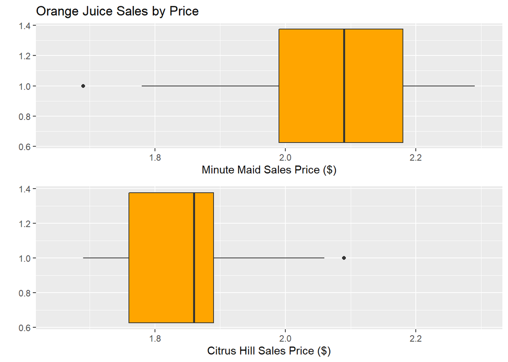

```r
#add similar box plot to clarify distributions
grid.arrange(
ggplot(data = oj_data, mapping = aes(x = 1)) +
  geom_boxplot(mapping = aes(y = PriceMM - DiscMM), fill = 'orange') +
  coord_flip() +
  ylim(1.65,2.3) +
  xlab('') +
  ylab('Minute Maid Sales Price ($)') +
  ggtitle('Orange Juice Sales by Price'),

ggplot(data = oj_data, mapping = aes(x = 1)) +
  geom_boxplot(mapping = aes(y = PriceCH - DiscCH), fill = 'orange') +
  coord_flip() +
  ylim(1.65,2.3) +
  xlab('') +
  ylab('Citrus Hill Sales Price ($)'),

ncol = 1)
```

```r
# ggsave(filename = 'OJ_prices_boxplot.png', plot = last_plot() + ggtitle('Orange Juice Sales by Price'))
```

- Confirmed average price and overall distribution of price is lower for Citris Hill

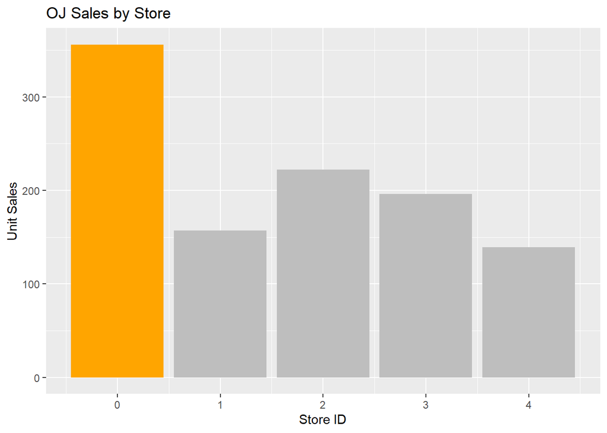

```r
#Bar plot for store sales distribution

ggplot(data = oj_data, mapping = aes(x = STORE)) +
  geom_bar(fill = c('orange','grey','grey','grey','grey')) +
  ylab('Unit Sales') +
  xlab('Store ID') +
  ggtitle('OJ Sales by Store')
```

```r
  #colored sales leader orange to stick out
```